# Exploring causal inference designs

Francesca Mancini

2026-02-24

First load the data.

```r
all_data <- readRDS("./Data/beewalk_drivers_merged.rds")
str(all_data)
```

[output not shown]

[output cut: 151 more lines]

[output not shown]

We are interested in the effect of temperature on bumblebee abundance. Let’s pick one species for now, *Bombus hypnorum*, a common and widespread species.

```r
all_data_1sp <- all_data %>%
  filter(latin == "Bombus hypnorum")
```

Now we fit a GLMM with mean temperature as a covariate and a random effect for site.

```r
re_model_temp <- glmmTMB(
  TotalCount ~ temp_mean + (1|GridReference),
  data = all_data_1sp,
  family = nbinom1
)

summary(re_model_temp)
```

```
##  Family: nbinom1  ( log )
## Formula:          TotalCount ~ temp_mean + (1 | GridReference)
## Data: all_data_1sp
##
##       AIC       BIC    logLik -2*log(L)  df.resid
##   36203.0   36231.5  -18097.5   36195.0      9053
##
## Random effects:
##
## Conditional model:
##  Groups        Name        Variance Std.Dev.
##  GridReference (Intercept) 0.04781  0.2187
## Number of obs: 9057, groups:  GridReference, 784
##
## Dispersion parameter for nbinom1 family (): 1.19
##
## Conditional model:
##             Estimate Std. Error z value Pr(>|z|)
## (Intercept)  1.18040    0.14135   8.351  < 2e-16 ***
## temp_mean   -0.03801    0.01337  -2.843  0.00446 **
## ---
## Signif. codes:  0 '***' 0.001 '**' 0.01 '*' 0.05 '.' 0.1 ' ' 1
```

Effect of tempearture is significant and the coefficient is negative (-0.03).

Now we fit a fixed effect panel regression with a fixed effect for site. This accounts for time invarying site confounders (variables that vary by site but not by time).

```r
mod_fe <- fenegbin(
  TotalCount ~ temp_mean | GridReference,
  data = all_data_1sp,
  cluster = ~ GridReference # clustered SEs as per Dee et al.
)
```

```
## NOTES: 1,106 observations removed because of NA values (RHS: 1,106).
##        100 fixed-effects (100 observations) removed because of only 0 outcomes or singletons.
```

```r
summary(mod_fe)
```

```
## ML estimation, family = Negative Binomial, Dep. Var.: TotalCount
## Observations: 8,957
## Fixed-effects: GridReference: 684
## Standard-errors: Clustered (GridReference)
##            Estimate Std. Error  z value Pr(>|z|)
## temp_mean -0.111868   0.060654 -1.84438 0.065128 .
## ---
## Signif. codes:  0 '***' 0.001 '**' 0.01 '*' 0.05 '.' 0.1 ' ' 1
## Over-dispersion parameter: theta = 2.682019
## Log-Likelihood: -16,554.6   Adj. Pseudo R2: 0.043172
##            BIC:  39,342.9     Squared Cor.: 0.108444
```

```r
mod_fe2 <- fenegbin(
  TotalCount ~ temp_mean | GridReference + Year,
  data = all_data_1sp,
  cluster = ~ GridReference # clustered SEs as per Dee et al.
)
```

```
## NOTES: 1,106 observations removed because of NA values (RHS: 1,106).
##        100/0 fixed-effects (100 observations) removed because of only 0 outcomes or singletons.
```

```r
summary(mod_fe2)
```

```
## ML estimation, family = Negative Binomial, Dep. Var.: TotalCount
## Observations: 8,957
## Fixed-effects: GridReference: 684,  Year: 11
## Standard-errors: Clustered (GridReference)
##           Estimate Std. Error z value Pr(>|z|)
## temp_mean 0.205075   0.156879 1.30722  0.19114
## ---
## Signif. codes:  0 '***' 0.001 '**' 0.01 '*' 0.05 '.' 0.1 ' ' 1
## Over-dispersion parameter: theta = 2.700578
## Log-Likelihood: -16,536.2   Adj. Pseudo R2: 0.043642
##            BIC:  39,397.0     Squared Cor.: 0.110003
```

This changes the sign of the coefficient and the p value is even larger. It’s possible that we don’t have enough power due to the fixed effects.

The next two designs allow us to do the same without the inefficiency of the fixed effects.

```r
GMCov <- glmmTMB(
  TotalCount ~ temp_mean + site_mean_temp + (1|GridReference),
  data = all_data_1sp,
  family = nbinom1
)

summary(GMCov)
```

```
##  Family: nbinom1  ( log )
## Formula:          TotalCount ~ temp_mean + site_mean_temp + (1 | GridReference)
## Data: all_data_1sp
##
##       AIC       BIC    logLik -2*log(L)  df.resid
##   36202.9   36238.5  -18096.4   36192.9      9052
##
## Random effects:
##
## Conditional model:
##  Groups        Name        Variance Std.Dev.
##  GridReference (Intercept) 0.04782  0.2187
## Number of obs: 9057, groups:  GridReference, 784
##
## Dispersion parameter for nbinom1 family (): 1.19
##
## Conditional model:
##                Estimate Std. Error z value Pr(>|z|)
## (Intercept)     1.10698    0.15010   7.375 1.64e-13 ***
## temp_mean      -0.08650    0.03580  -2.416   0.0157 *
## site_mean_temp  0.05543    0.03796   1.460   0.1442
## ---
## Signif. codes:  0 '***' 0.001 '**' 0.01 '*' 0.05 '.' 0.1 ' ' 1
```

This is telling us that the effect of temperature is negative and significant. The contextual effect (the effect of site mean temperature) is close to 0, which in theory means that there are no site level confounders and therefore a mixed model is enough.

But the mean tem[erature and site mean tem[perature are strongly correlated, which makes the previous model not appropriate.

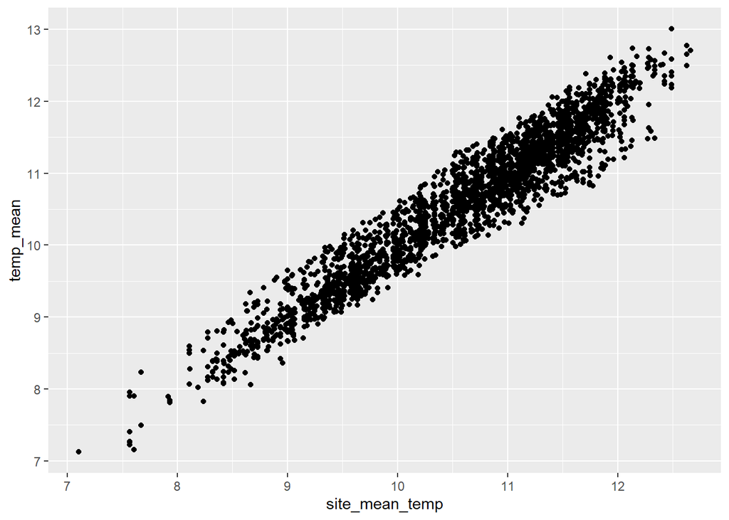

```r
ggplot(all_data_1sp,
       aes(x = site_mean_temp, y = temp_mean)) +
  geom_point()
```

The Group Mean Centered design removes this correlation by centering the causal variable around the site average. In this case we create a anomaly temperature variable, by subtracting the site mean temperature scross years from the average temperature for that year.

```r
# first derive the site temperature anomaly (temp variable centered around the average site temp)

all_data_1sp <- all_data_1sp %>%
  mutate(temp_cent = temp_mean - site_mean_temp)


GMCent <- glmmTMB(
  TotalCount ~ temp_cent + site_mean_temp + (1|GridReference),
  data = all_data_1sp,
  family = nbinom1
)

summary(GMCent)
```

```
##  Family: nbinom1  ( log )
## Formula:          TotalCount ~ temp_cent + site_mean_temp + (1 | GridReference)
## Data: all_data_1sp
##
##       AIC       BIC    logLik -2*log(L)  df.resid
##   36202.9   36238.5  -18096.4   36192.9      9052
##
## Random effects:
##
## Conditional model:
##  Groups        Name        Variance Std.Dev.
##  GridReference (Intercept) 0.04782  0.2187
## Number of obs: 9057, groups:  GridReference, 784
##
## Dispersion parameter for nbinom1 family (): 1.19
##
## Conditional model:
##                Estimate Std. Error z value Pr(>|z|)
## (Intercept)     1.10698    0.15010   7.375 1.64e-13 ***
## temp_cent      -0.08650    0.03580  -2.416   0.0157 *
## site_mean_temp -0.03107    0.01418  -2.191   0.0285 *
## ---
## Signif. codes:  0 '***' 0.001 '**' 0.01 '*' 0.05 '.' 0.1 ' ' 1
```

The effect of mean temperature is negative and the same as estimated by the previous model. But now we have removed the correlation between the two variables. The effect of site mean temperature is also negative, but this includes unmeasured confounders that vary across sites as well so it cannot be interpreted causally.

The differencing designs are useful to separate correlated drivers (confounders that have the same temporal trend as the causal variable) that vary by site as well. We use a second differencing design as we are not particularly interested in site specific trends.

```r
data_sd <- all_data_1sp %>%
  arrange(GridReference, Year) %>%
  group_by(GridReference) %>%
  mutate(
    dy = TotalCount - lag(TotalCount),
    dx = temp_mean - lag(temp_mean),
    d2y = dy - lag(dy),
    d2x = dx - lag(dx)
  ) %>%
  ungroup() %>%
  filter(!is.na(d2y), !is.na(d2x))

sDiff <- lm(d2y ~ d2x, data = data_sd)
summary(sDiff)
```

```
##
## Call:
## lm(formula = d2y ~ d2x, data = data_sd)
##
## Residuals:
##     Min      1Q  Median      3Q     Max
## -494.97   -0.97    0.03    2.03  250.03
##
## Coefficients:
##             Estimate Std. Error t value Pr(>|t|)
## (Intercept) -0.03339    0.13043  -0.256    0.798
## d2x         -0.40099    0.46814  -0.857    0.392
##
## Residual standard error: 11.36 on 7587 degrees of freedom
## Multiple R-squared:  9.669e-05,  Adjusted R-squared:  -3.51e-05
## F-statistic: 0.7337 on 1 and 7587 DF,  p-value: 0.3917
```

What does it all mean??